# Phase_3_last_Notebook_with_Deployment_comments

## Phase 3 - Deployment options

### Comments and final analysis

- this data science project starts with some business questions and some historical data (2004 to 2007)
- the objective of the project is to have some guidelines that could help business decisions related to next revenue year
- was not provided data for the year of 2008 to run the simulation / prediction

  ```
    ** in a normal situation can be used a much more complex dataset to run the prediction/simulation, with information such as inventory, marketing campaign, sales by day, month and year and so on...

    ** with all of these information a much more complex model can be build with even higher accuracy in the prediction
  ```

## Initial Business Requirement

Business questions:

- Can we predict our revenue in 2008 ?
- What is the confidence of this prediction ?
- And finally, if we sell the same products from 2007, what are the divergence expected on revenue in 2008 ?

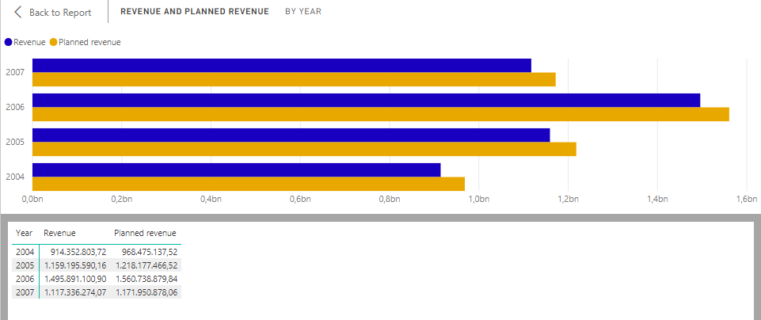

```python
from IPython.display import Image
Image('./Sales_Marketing_Revenue_vs_Planned_Revenue_Phase_0.PNG')
```

## Insights and findings -> Business answers

#### Top 3 features that impact the revenue

- Product
- Retailer country and
- Order method type

#### High prediction confidence achieved with R^2 of 0.9016

#### Basic estimation of revenue compared with 2 years

** Based on the assumption to sell the same products of the year 2007

- Revenue prediction for 2008 are expected to be 2.5% smaller than the year 2005 and
- Revenue prediction for 2008 are expected to be 1.5% higher than the last year (year 2007)

## Revenue prediction

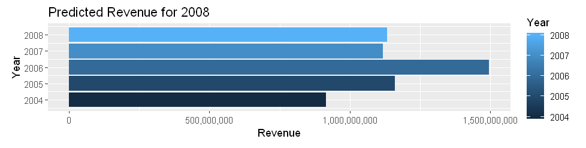

```python
from IPython.display import Image
Image('./Phase_3_Revenue_prediction_2008.PNG')
```

### Deployment options and considerations

- The best deployment / final delivery in this type of scenario is provide information as requested and do not to automate the prediciton

  ** run all simulation according with the new requirements -> build the model, analyse the results and provide new Insights
- One important point not mentioned yet that could provide better results also is build together with Line of Business users predictions / simulation to target the Revenue to be higher than the Planned Revenue

  -> You can see in the first chart above that all revenue achieved from 2004 to 2007 is quite low related to the planned revenue

  -> Go deep into the prediction related to products and product lines and order methods to increase revenue in specific regions and so on
- Many business process can be designed to achieve higher revenue. Use this type of statistical methodology to feel more confident to apply these changes

```python
print(' THE END.')
```

```
 THE END.
```